# Biomass analysis (PatchSizePilot)

Emanuele Giacomuzzo

2022-07-07

Here I study how **biomass density** changes across treatments in the PatchSizePilot. In particular, I’m studying how biomass density changes across:

- ecosystems of different size (this is the case in nature, but we need to make sure that it’s the case also in our experiment)
- ecosystems that are connected (through the flow of nutrients) to an ecosystem of the same size or to an ecosystem that is larger
- meta-ecosystems in which patch size is the same or in which one patch has most of the area (we keep the total area of the meta-ecosystem constant)

# Import

```r
culture_info = read.csv(here("data", "PatchSizePilot_culture_info.csv"), header = TRUE)
load(here("data", "population", "t0.RData")); t0 = pop_output
load(here("data", "population", "t1.RData")); t1 = pop_output
load(here("data", "population", "t2.RData")); t2 = pop_output
load(here("data", "population", "t3.RData")); t3 = pop_output
load(here("data", "population", "t4.RData")); t4 = pop_output
load(here("data", "population", "t5.RData")); t5 = pop_output
load(here("data", "population", "t6.RData")); t6 = pop_output
load(here("data", "population", "t7.RData")); t7 = pop_output
rm(pop_output)
```

# Tidy

```r
t0$time = NA
t1$time = NA

t0$replicate_video = 1:12 #In t1 I took 12 videos of a single
t1$replicate_video = 1 #In t1 I took only 1 video/culture
t2$replicate_video = 1 #In t2 I took only 1 video/culture
t3$replicate_video = 1 #In t3 I took only 1 video/culture
t4$replicate_video = 1 #In t4 I took only 1 video/culture
t5$replicate_video = 1 #In t5 I took only 1 video/culture
t6$replicate_video = t6$replicate; t6$replicate = NULL
t7$replicate_video = t7$replicate; t7$replicate = NULL

#Create an elongated version of t0 so that each of the 110 cultures can have 12 video replicates at t0.
elongating_t0 = NULL
for (video in 1:nrow(t0)){
  for (ID in 1:nrow(culture_info)) {
    elongating_t0 = rbind(elongating_t0, t0[video,])
  }
}

ID_vector = rep(1:nrow(culture_info), times = nrow(t0))
elongating_t0$culture_ID = ID_vector

t0 = merge(culture_info,elongating_t0, by="culture_ID")
t1 = merge(culture_info,t1,by="culture_ID")
t2 = merge(culture_info,t2,by="culture_ID")
t3 = merge(culture_info,t3,by="culture_ID")
t4 = merge(culture_info,t4,by="culture_ID")
t5 = merge(culture_info,t5,by="culture_ID")
t6 = merge(culture_info,t6,by="culture_ID")
t7 = merge(culture_info,t7,by="culture_ID")
ds = rbind(t0, t1, t2, t3, t4, t5, t6, t7); rm(elongating_t0, t0, t1, t2, t3, t4, t5, t6, t7)

# Switch from data point to day
ds$day = ds$time_point; ds$time_point = NULL
ds$day[ds$day=="t0"] = "0"
ds$day[ds$day=="t1"] = "4"
ds$day[ds$day=="t2"] = "8"
ds$day[ds$day=="t3"] = "12"
ds$day[ds$day=="t4"] = "16"
ds$day[ds$day=="t5"] = "20"
ds$day[ds$day=="t6"] = "24"
ds$day[ds$day=="t7"] = "28"
ds$day = as.numeric(ds$day)

ds = ds %>%
  select(culture_ID, patch_size, disturbance, metaecosystem_type, bioarea_per_volume, replicate_video, day, metaecosystem, system_nr, eco_metaeco_type)
ds = ds[, c("culture_ID", "system_nr", "disturbance", "day", "patch_size", "metaecosystem", "metaecosystem_type", "eco_metaeco_type", "replicate_video","bioarea_per_volume")]

ds$eco_metaeco_type = factor(ds$eco_metaeco_type, levels=c('S', 'S (S_S)', 'S (S_L)', 'M', 'M (M_M)', 'L', 'L (L_L)', 'L (S_L)'))
```

```r
ds_regional = ds %>%
    group_by(culture_ID, system_nr, disturbance, day, patch_size, metaecosystem_type) %>%
    summarise(patch_mean_bioarea_across_videos = mean(bioarea_per_volume)) %>%
    group_by(system_nr, disturbance, day,metaecosystem_type) %>%
    summarise(regional_mean_bioarea = mean(patch_mean_bioarea_across_videos))
```

# Plot

## Biomass @ low disturbance

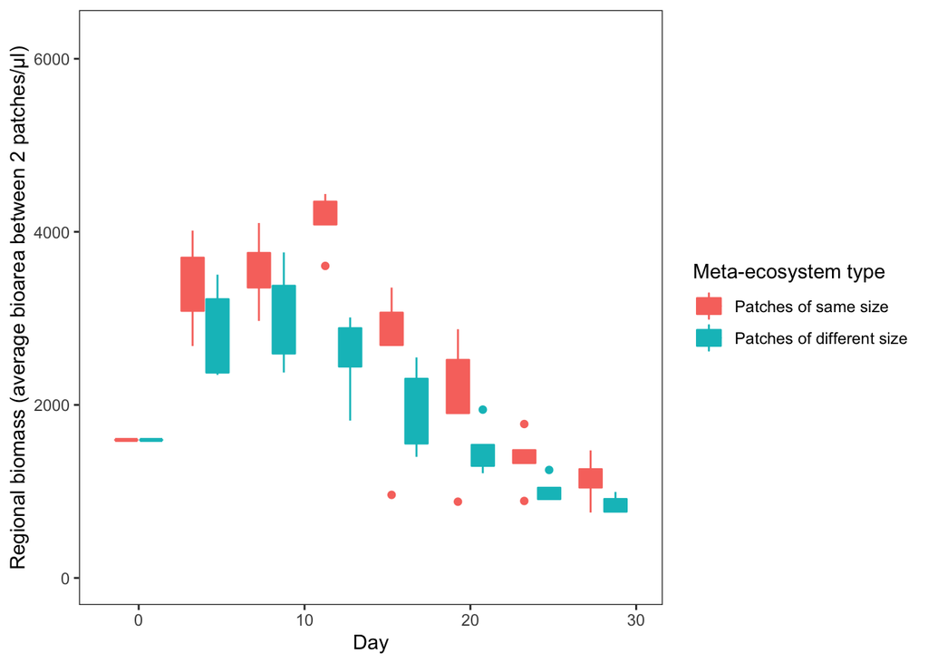

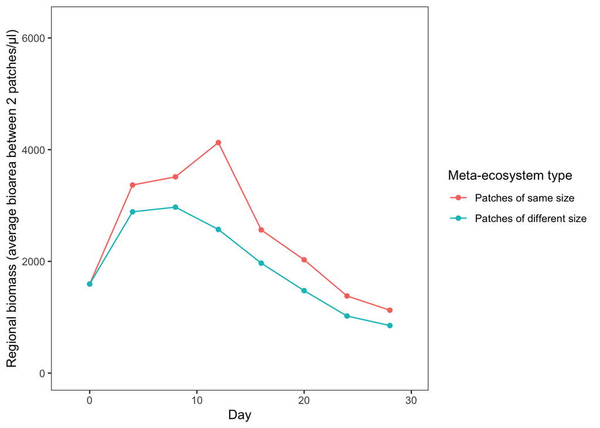

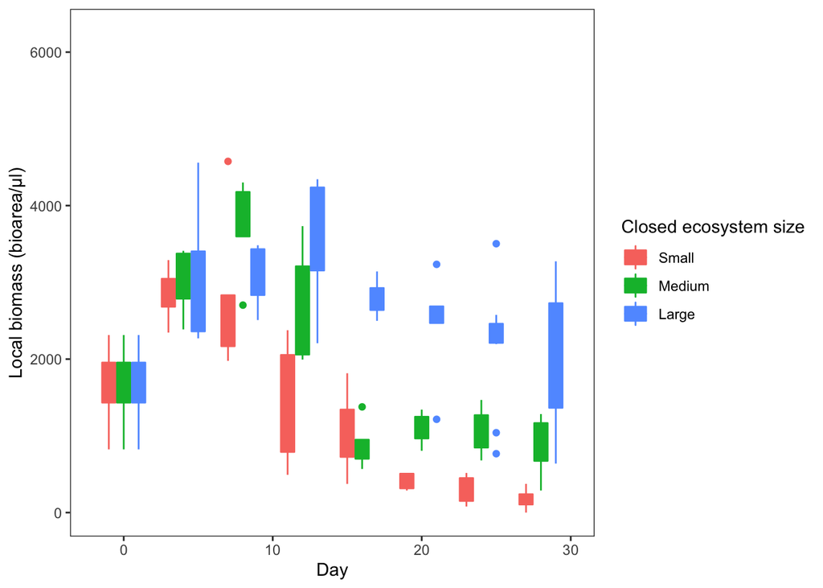

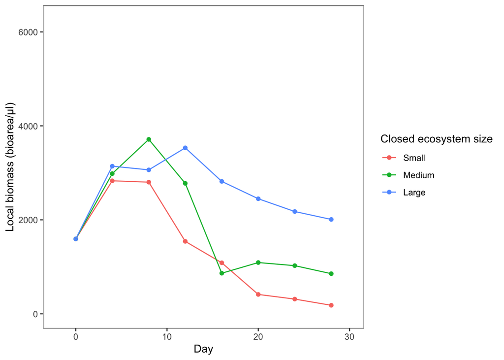

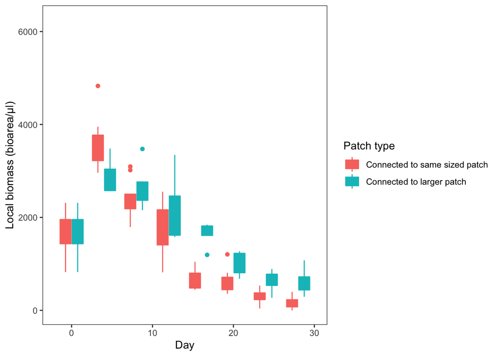

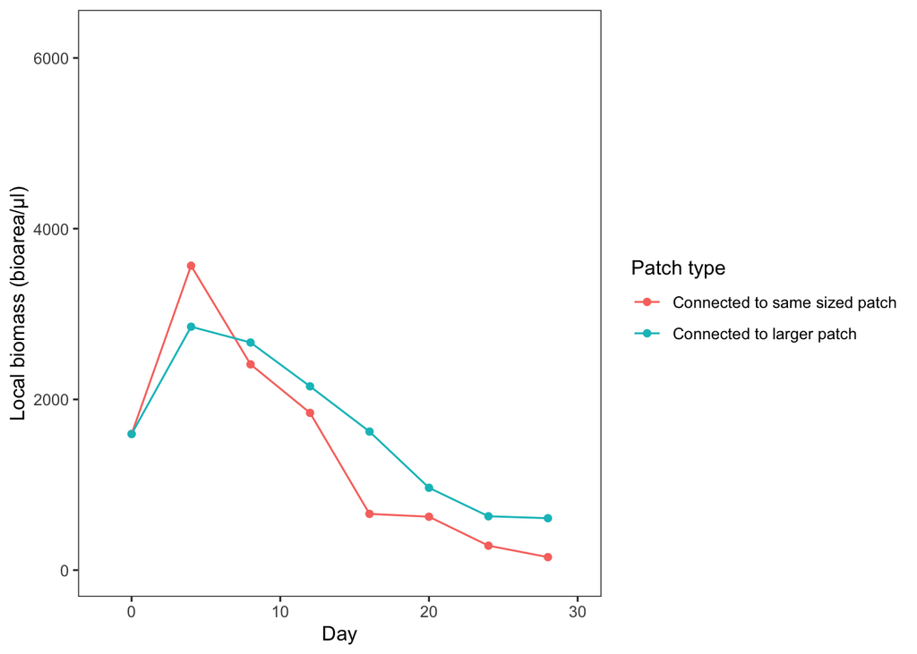

Let’s now save all the plots together in a single image. As the single image is too large for R markdown, it cannot be displayed here.

```r
grid = grid.arrange(p[[1]],p[[3]],p[[5]],p[[2]],p[[4]],p[[6]],
                    ncol=3, nrow=2,
                    top = textGrob("Low disturbance",gp=gpar(fontsize=20,font=3)))
ggsave(here("results", "biomass", "Clean_biomass_low.jpg"), grid, width = 22, height = 13)
```

## Biomass @ high disturbance

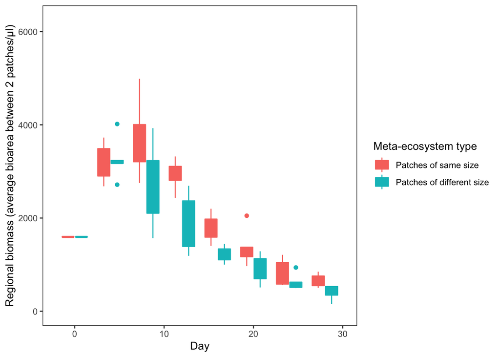

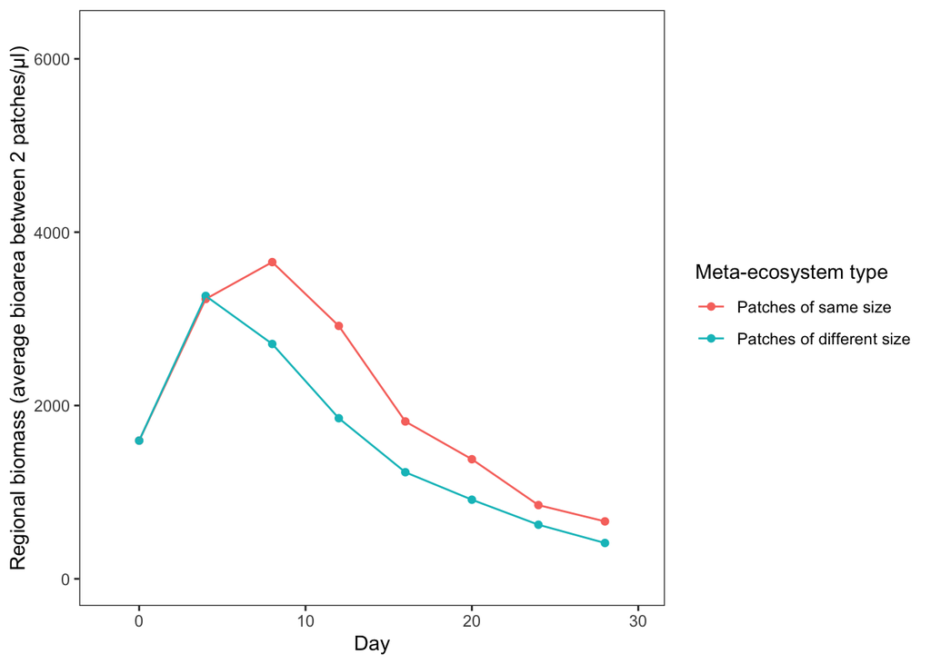

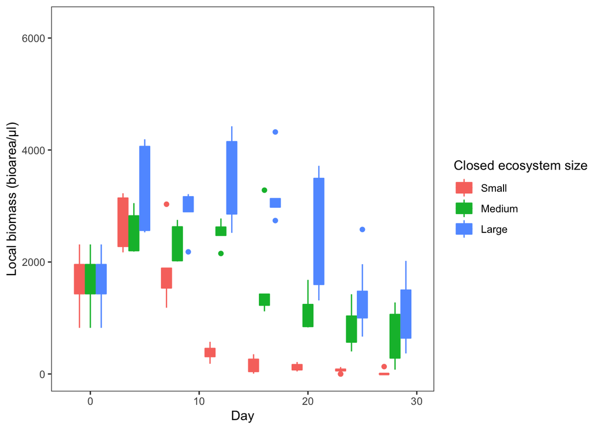

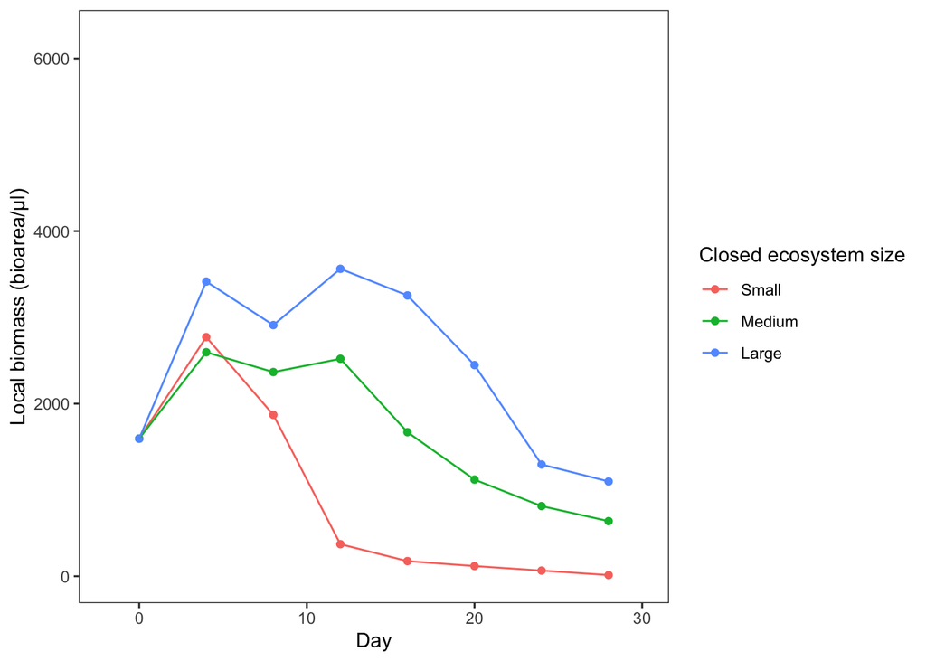

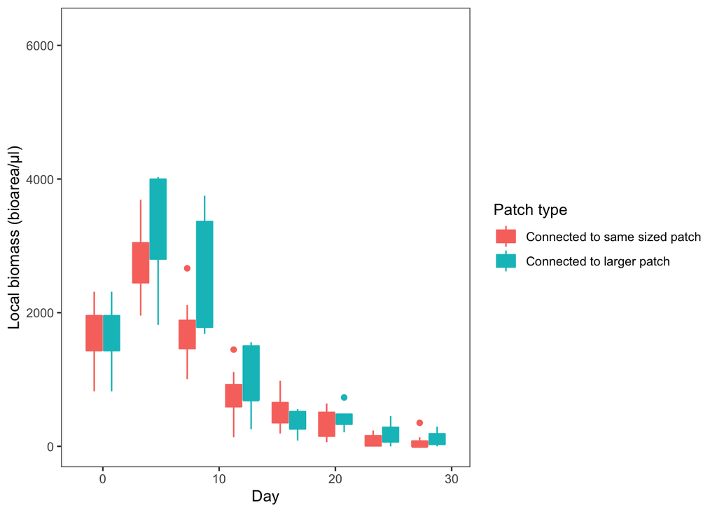

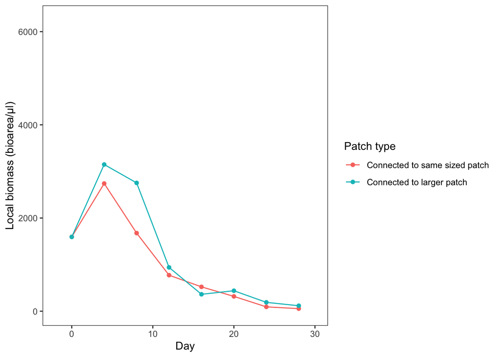

Let’s save also here for high disturbance.

```r
biomass_plots("high")
grid = grid.arrange(p[[1]],p[[3]],p[[5]],p[[2]],p[[4]],p[[6]],
             ncol=3, nrow=2,
             top = textGrob("High disturbance",gp=gpar(fontsize=20,font=3)))
ggsave(here("results", "biomass", "Clean_biomass_high.jpg"), grid, width = 22, height = 13)
```

# Mixed effect models

To build the mixed effect models we will use the R package lme4. See page 6 of [this PDF](https://cran.r-project.org/web/packages/lme4/vignettes/lmer.pdf) to know more about the syntaxis of this package.

To do model diagnostics, I’m going to look at the following two plots (as suggested by Zuur et al. (2009), page 487):

- Quantile-quantile plots
- Partial residual plots

## Regional biomass - all time points

When modelling the regional biomass, we want to understand if the regional biomass produced by an ecosystem with a small and a large patch (metaecosystem_type = S_L) is lower than the regional biomass produced by an ecosystem with two medium patches (metaecosystem_type = M_M).

### Create regional biomass data set

First of all, let’s produce a data set including the regional biomass of all our meta ecosystems. In this data set, not only we want to have the regional biomass of the meta-ecosystems (averaged first across videos and then across patches) but also:

- We want to include only the meta-ecosystems in which patches had both medium size (metaecosystem_type = M_M) and meta-ecosystems in which patches had one a small size and the other large size (metaecosystem_type = S_L).
- We want to take off the first time point (day = 0). This is because all the meta-ecosystems had the same regional biomass, which was a construct of our experimental design.

```r
ds_regional_shrunk_type_n_day = ds_regional %>%
    filter (metaecosystem_type == "M_M" | metaecosystem_type == "S_L", day != 0)
```

### Model selection

First of all, let’s include time as a random variable. Let’s start from the largest mixed effect model makes sense to construct. This will include:

- As fixed effect: disturbance, metaecosystem type, and their interaction
- As random effect (random intercept and slope): day and the number of the metaecosystem (system_nr).

We are actually going to construct two full models. One with the correlated and one with the uncorrelated random slopes and intercept, the other without.

```r
#Uncorrelated intercepts and slopes
full_model = lmer(regional_mean_bioarea ~ metaecosystem_type  + disturbance + metaecosystem_type * disturbance + (metaecosystem_type || day) + (disturbance || day) + (metaecosystem_type*disturbance  || day) + (metaecosystem_type || system_nr) + (disturbance || system_nr) + (metaecosystem_type*disturbance  || system_nr), data = ds_regional_shrunk_type_n_day, REML = FALSE)

#Correlated intercepts and slopes
full_model_correlated = lmer(regional_mean_bioarea ~ metaecosystem_type  + disturbance + metaecosystem_type * disturbance + (metaecosystem_type | day) + (disturbance | day) + (metaecosystem_type*disturbance  | day) + (metaecosystem_type | system_nr) + (disturbance | system_nr) + (metaecosystem_type*disturbance  | system_nr), data = ds_regional_shrunk_type_n_day, REML = FALSE)

anova(full_model, full_model_correlated)
```

```
## Data: ds_regional_shrunk_type_n_day
## Models:
## full_model_correlated: regional_mean_bioarea ~ metaecosystem_type + disturbance + metaecosystem_type * disturbance + (metaecosystem_type | day) + (disturbance | day) + (metaecosystem_type * disturbance | day) + (metaecosystem_type | system_nr) + (disturbance | system_nr) + (metaecosystem_type * d…
## full_model: regional_mean_bioarea ~ metaecosystem_type + disturbance + metaecosystem_type * disturbance + ((1 | day) + (0 + metaecosystem_type | day)) + ((1 | day) + (0 + disturbance | day)) + ((1 | day) + (0 + metaecosystem_type | day) + (0 + disturbance | day) + (0 + metaecosystem_type:disturba…
##                       npar    AIC    BIC  logLik deviance Chisq Df Pr(>Chisq)
## full_model_correlated   37 2221.3 2330.2 -1073.7   2147.3
## full_model              55 2257.3 2419.1 -1073.7   2147.3     0 18          1
```

Although the AIC for the model with correlated slopes is lower, there is not statistical significance between the two models. Let’s then keep as a full model the one with non correlated slopes (full_model).

#### *Meta-ecosystem ID random effect*

Should we keep the random effect of the metaecosystem number?

```r
no_system_nr_model = lmer(regional_mean_bioarea ~ metaecosystem_type  + disturbance + metaecosystem_type * disturbance + (metaecosystem_type || day) + (disturbance || day) + (metaecosystem_type*disturbance || day), data = ds_regional_shrunk_type_n_day, REML = FALSE)

anova(full_model, no_system_nr_model)
```

```
## Data: ds_regional_shrunk_type_n_day
## Models:
## no_system_nr_model: regional_mean_bioarea ~ metaecosystem_type + disturbance + metaecosystem_type * disturbance + ((1 | day) + (0 + metaecosystem_type | day)) + ((1 | day) + (0 + disturbance | day)) + ((1 | day) + (0 + metaecosystem_type | day) + (0 + disturbance | day) + (0 + metaecosystem_type:…
## full_model: regional_mean_bioarea ~ metaecosystem_type + disturbance + metaecosystem_type * disturbance + ((1 | day) + (0 + metaecosystem_type | day)) + ((1 | day) + (0 + disturbance | day)) + ((1 | day) + (0 + metaecosystem_type | day) + (0 + disturbance | day) + (0 + metaecosystem_type:disturba…
##                    npar    AIC    BIC  logLik deviance  Chisq Df Pr(>Chisq)
## no_system_nr_model   30 2217.1 2305.4 -1078.5   2157.1
## full_model           55 2257.3 2419.1 -1073.7   2147.3 9.7713 25     0.9972
```

The difference between the two doesn’t seem to be significant. Therefore, let’s throw out the system_nr from our model.

#### *Random effects*

Should we keep the random effects?

```r
fixed_effects_model = lm(regional_mean_bioarea ~ metaecosystem_type  + disturbance, data = ds_regional_shrunk_type_n_day)

anova(no_system_nr_model, fixed_effects_model)
```

```
## Data: ds_regional_shrunk_type_n_day
## Models:
## fixed_effects_model: regional_mean_bioarea ~ metaecosystem_type + disturbance
## no_system_nr_model: regional_mean_bioarea ~ metaecosystem_type + disturbance + metaecosystem_type * disturbance + ((1 | day) + (0 + metaecosystem_type | day)) + ((1 | day) + (0 + disturbance | day)) + ((1 | day) + (0 + metaecosystem_type | day) + (0 + disturbance | day) + (0 + metaecosystem_type:…
##                     npar    AIC    BIC  logLik deviance  Chisq Df Pr(>Chisq)
## fixed_effects_model    4 2363.1 2374.9 -1177.6   2355.1
## no_system_nr_model    30 2217.1 2305.4 -1078.5   2157.1 198.02 26  < 2.2e-16
##
## fixed_effects_model
## no_system_nr_model  ***
## ---
## Signif. codes:  0 '***' 0.001 '**' 0.01 '*' 0.05 '.' 0.1 ' ' 1
```

The full model is better, as we expected. Time plays such an important part in explaining the way that biomass changes.

#### *Interaction between metaecosystem and disturbance*

Should we keep the interaction between metaecosystem and disturbance?

```r
no_interaction_model = lmer(regional_mean_bioarea ~ metaecosystem_type + disturbance  + (metaecosystem_type || day) + (disturbance || day), data = ds_regional_shrunk_type_n_day, REML = FALSE)

anova(no_system_nr_model, no_interaction_model)
```

```
## Data: ds_regional_shrunk_type_n_day
## Models:
## no_interaction_model: regional_mean_bioarea ~ metaecosystem_type + disturbance + ((1 | day) + (0 + metaecosystem_type | day)) + ((1 | day) + (0 + disturbance | day))
## no_system_nr_model: regional_mean_bioarea ~ metaecosystem_type + disturbance + metaecosystem_type * disturbance + ((1 | day) + (0 + metaecosystem_type | day)) + ((1 | day) + (0 + disturbance | day)) + ((1 | day) + (0 + metaecosystem_type | day) + (0 + disturbance | day) + (0 + metaecosystem_type:…
##                      npar    AIC    BIC  logLik deviance  Chisq Df Pr(>Chisq)
## no_interaction_model   12 2183.2 2218.4 -1079.6   2159.2
## no_system_nr_model     30 2217.1 2305.4 -1078.5   2157.1 2.0436 18          1
```

There is no statistical significance between the two models. Therefore, let’s drop the interaction between disturbance and meta-ecosystem type.

#### *Random slopes*

Should we keep the random slopes?

```r
no_slopes_model = lmer(regional_mean_bioarea ~ metaecosystem_type + disturbance  + (1 | day), data = ds_regional_shrunk_type_n_day, REML = FALSE)

anova(no_interaction_model, no_slopes_model)
```

```
## Data: ds_regional_shrunk_type_n_day
## Models:
## no_slopes_model: regional_mean_bioarea ~ metaecosystem_type + disturbance + (1 | day)
## no_interaction_model: regional_mean_bioarea ~ metaecosystem_type + disturbance + ((1 | day) + (0 + metaecosystem_type | day)) + ((1 | day) + (0 + disturbance | day))
##                      npar    AIC    BIC  logLik deviance  Chisq Df Pr(>Chisq)
## no_slopes_model         5 2185.8 2200.5 -1087.9   2175.8
## no_interaction_model   12 2183.2 2218.4 -1079.6   2159.2 16.598  7    0.02018 *
## ---
## Signif. codes:  0 '***' 0.001 '**' 0.01 '*' 0.05 '.' 0.1 ' ' 1
```

Yes. We should keep the random slopes. Well, it seems like this is our best model then.

### Best model

#### Without fitting function to time dynamics

##### Effect size & significance

After model selection, we determined that the best model is the following one:

`regional_mean_bioarea ~ metaecosystem_type + disturbance + (metaecosystem_type || day) + (disturbance || day)`

coded as

`lmer(regional_mean_bioarea ~ metaecosystem_type + disturbance + (metaecosystem_type || day) + (disturbance || day), data = ds_regional_shrunk_type_n_day, REML = FALSE)`

Let’s call it then `best_model` to don’t get confused.

```r
best_model = no_interaction_model
```

###### Effect size & significance of best model

Let’s now calculate the statistical significance and effect size of the best model. The marginal and conditional r squared are calculated using the package `MuMIn`. For the coding and interpretation of these r squared check the [documentation for the r.squaredGLMM function](https://rdrr.io/cran/MuMIn/man/r.squaredGLMM.html).

```r
model.null = lmer(regional_mean_bioarea ~ (1 | day), data = ds_regional_shrunk_type_n_day, REML = FALSE)

r2_best = r.squaredGLMM(best_model)
r2_best = round(r2_best, digits = 3)

anova = anova(best_model, model.null)
p_best = anova$`Pr(>Chisq)`[2]
p_best = round(p_best, digits = 5)

if (p_best < 0.00001) {
  p_best = "< 0.00001"
}
```

###### Effect size & significance of meta-ecosystem type (in the best model)

```r
metaecosystem_type_null = lmer(regional_mean_bioarea ~  disturbance  + (disturbance || day),
                               data = ds_regional_shrunk_type_n_day,
                               REML = FALSE,
                               control = lmerControl(optimizer ='optimx',
                                                     optCtrl=list(method='L-BFGS-B')))

r2_no_metaecosystem_type = r.squaredGLMM(metaecosystem_type_null)
r2_no_metaecosystem_type = round(r2_no_metaecosystem_type, digits = 3)

anova = anova(best_model, metaecosystem_type_null)
p_no_metaecosystem_type = anova$`Pr(>Chisq)`[2]
p_no_metaecosystem_type = round(p_no_metaecosystem_type, digits = 5)

if (p_no_metaecosystem_type < 0.00001) {
  p_no_metaecosystem_type = "< 0.00001"
}
```

###### Effect size & significance of disturbance (in the best model)

```r
disturbance_null = lmer(regional_mean_bioarea ~ metaecosystem_type  + (metaecosystem_type || day),
                        data = ds_regional_shrunk_type_n_day,
                        REML = FALSE,
                        control = lmerControl(optimizer ='optimx',
                                                     optCtrl=list(method='L-BFGS-B')))

r2_no_disturbance = r.squaredGLMM(disturbance_null)
r2_no_disturbance = round(r2_no_disturbance, digits = 3)

anova = anova(best_model, disturbance_null)
p_no_disturbance = anova$`Pr(>Chisq)`[2]
p_no_disturbance = round(p_no_disturbance, digits = 5)

if (p_no_disturbance < 0.00001) {
  p_no_disturbance = "< 0.00001"
}
```

The effect size and significance of our results can be found in the following table.

| Model | Marginal R2 | Marginal R2 of the best model explained | Conditional R2 | Conditional R2 of the best model explained | P-value |
| --- | --- | --- | --- | --- | --- |
| Best model | 0.077 | / | 0.872 | / | < 0.00001 |
| Best model without meta-ecosystem type | 0.039 | 0.038 | 0.746 | 0.126 | < 0.00001 |
| Best model without disturbance | 0.06 | 0.017 | 0.77 | 0.102 | < 0.00001 |

This means that meta-ecosystem type should explain more than disturbance regional biomass dynamics. However, the effect size isn’t that high (0.038). Because of this, we thought we should fit a function to the time dynamics of the regional biomass.

#### Fitting function to time dynamics

Here we want to fit how biomass changes across time to a function. The biomass of our meta-ecosystems looks like this.

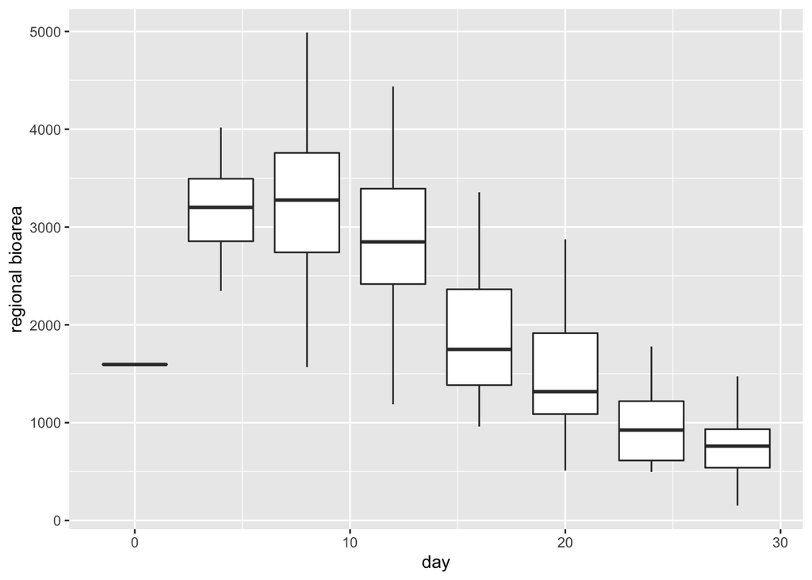

```r
ds_regional_shrunk_type = ds_regional %>%
    filter(metaecosystem_type == "M_M" | metaecosystem_type == "S_L")

ds_regional_shrunk_type%>%
  ggplot(aes(x = day,
             y = regional_mean_bioarea,
             group = day)) +
  geom_boxplot() +
  labs(x = "day", y = "regional bioarea")
```

To fit these data, we need to produce (and parameterise) a function that resemble how the biomass first increases and then decreases.

Hank produced the following function:

$$biomass = a_4 * (day - a_5) * e^{a_1(day
- a_5)}$$

If we parameterise the function and then plot, it looks as follows.

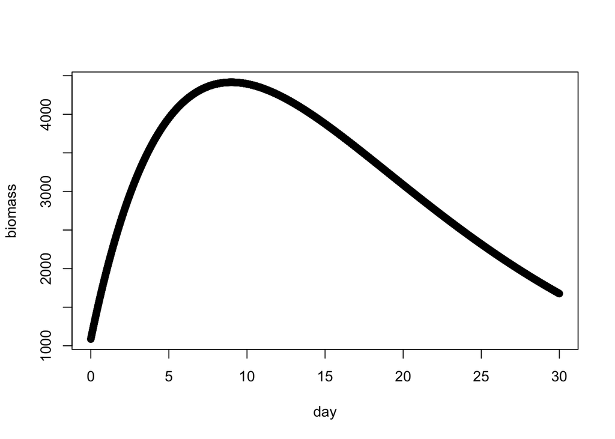

```r
a1 = -0.1
a4 = 1200
a5 = -1

day = seq(0, 30, 0.01)
biomass = a4*(day-a5) * exp(a1*(day-a5))
plot(biomass ~ day)
```

Now, let’s find the best parameters (a1, a4, a5) that fit our data.

```r
model = nls(regional_mean_bioarea ~ a4 * (day-a5) * exp(a1 * (day-a5)),
            start = list(a1 = -0.1, a4 = 1200, a5 = -1),
            trace = T,
            data = ds_regional_shrunk_type)
```

```
## 3.207146e+08 (2.20e+00): par = (-0.1 1200 -1)
## 6.412369e+07 (4.12e-01): par = (-0.1179228 1068.784 -1.67652)
## 5.487935e+07 (3.09e-02): par = (-0.131878 1191.706 -1.650935)
## 5.482745e+07 (6.04e-04): par = (-0.1336275 1216.39 -1.613925)
## 5.482743e+07 (1.27e-06): par = (-0.1336182 1216.427 -1.614735)
```

```r
model$m$getPars()
```

```
##           a1           a4           a5
##   -0.1336182 1216.4268967   -1.6147345
```

```r
a1 = as.numeric(model$m$getPars()[1])
a4 = as.numeric(model$m$getPars()[2])
a5 = as.numeric(model$m$getPars()[3])
```

And now let’s plot the function to see how it fits our data.

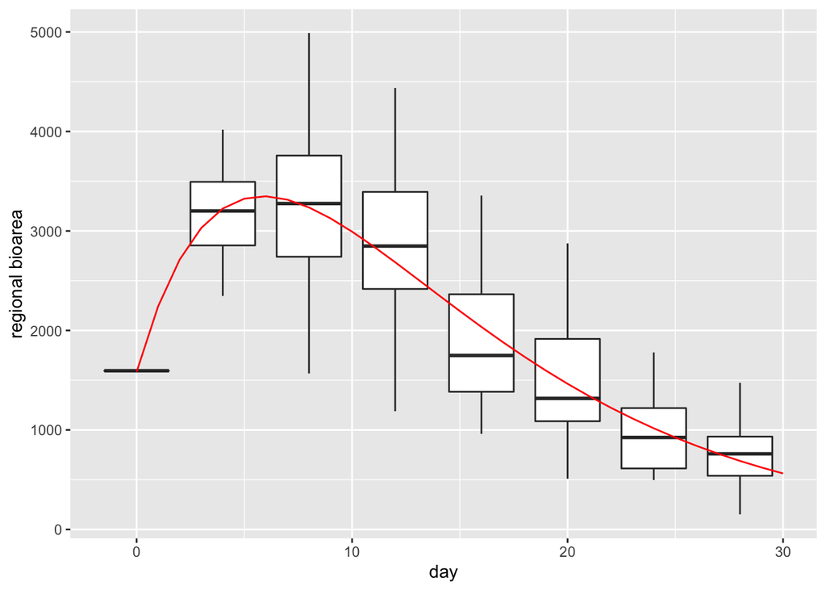

```r
day = seq(0,30,1)
predicted = a4*(day-a5)*exp(a1*(day-a5))
data_fitted=data.frame(day=day,regional_mean_bioarea=predicted)

ds_regional_shrunk_type%>%
  ggplot(aes(x = day,
             y = regional_mean_bioarea,
             group = day)) +
  geom_boxplot() +
  labs(x = "day", y = "regional bioarea") +
  geom_line(data=data_fitted,aes(x = day, y=regional_mean_bioarea),color="red", group = 1)
```

Okay great! Next step is to now integrate the predicted temporal dynamics.

```r
ds_regional = ds_regional %>%
  mutate(predicted_from_time = a4*(day-a5)*exp(a1*(day-a5)))
```

Let’s now integrate it into the mixed effect model!

```r
ds_regional_yo = ds_regional %>%
  filter(metaecosystem_type == "S_L" | metaecosystem_type == "M_M", day > 0)

model = lm(regional_mean_bioarea ~ predicted_from_time + metaecosystem_type  + disturbance, data = ds_regional_yo)
summary(model)
```

```
##
## Call:
## lm(formula = regional_mean_bioarea ~ predicted_from_time + metaecosystem_type +
##     disturbance, data = ds_regional_yo)
##
## Residuals:
##     Min      1Q  Median      3Q     Max
## -1581.4  -315.8     1.4   294.5  1699.5
##
## Coefficients:
##                         Estimate Std. Error t value Pr(>|t|)
## (Intercept)             53.36310  120.56722   0.443    0.659
## predicted_from_time      0.99994    0.04566  21.899  < 2e-16 ***
## metaecosystem_typeS_L -561.51098   87.71677  -6.401 2.31e-09 ***
## disturbancelow         452.43651   87.71677   5.158 8.64e-07 ***
## ---
## Signif. codes:  0 '***' 0.001 '**' 0.01 '*' 0.05 '.' 0.1 ' ' 1
##
## Residual standard error: 518.9 on 136 degrees of freedom
## Multiple R-squared:  0.8009, Adjusted R-squared:  0.7965
## F-statistic: 182.4 on 3 and 136 DF,  p-value: < 2.2e-16
```

Adjusted R-squared: 0.80.

```r
model = lm(regional_mean_bioarea ~ predicted_from_time + + disturbance, data = ds_regional_yo)
summary(model)
```

```
##
## Call:
## lm(formula = regional_mean_bioarea ~ predicted_from_time + +disturbance,
##     data = ds_regional_yo)
##
## Residuals:
##     Min      1Q  Median      3Q     Max
## -1440.8  -301.5     2.7   289.4  1980.3
##
## Coefficients:
##                      Estimate Std. Error t value Pr(>|t|)
## (Intercept)         -227.3924   127.6459  -1.781   0.0771 .
## predicted_from_time    0.9999     0.0519  19.267  < 2e-16 ***
## disturbancelow       452.4365    99.6970   4.538 1.23e-05 ***
## ---
## Signif. codes:  0 '***' 0.001 '**' 0.01 '*' 0.05 '.' 0.1 ' ' 1
##
## Residual standard error: 589.8 on 137 degrees of freedom
## Multiple R-squared:  0.7409, Adjusted R-squared:  0.7372
## F-statistic: 195.9 on 2 and 137 DF,  p-value: < 2.2e-16
```

Adjusted R-squared: 0.74.

Next steps:

- Do it for two different disturbance regimes
- Drop time points

## Regional biomass - dropping time points

```r
no_interaction_model = lmer(regional_mean_bioarea ~ metaecosystem_type + disturbance  + (metaecosystem_type || day) + (disturbance || day), data = ds_regional_shrunk_type_n_day, REML = FALSE)
```

# Bibliography

Zuur, Alain F., Elena N. Ieno, Neil Walker, Anatoly A. Saveliev, and Graham M. Smith. 2009. *Mixed effects models and extensions in ecology with R*. Vol. 36. Statistics for Biology and Health. New York, NY: Springer New York. https://doi.org/10.1007/978-0-387-87458-6.